# stream metabolizer SSS 021723 template

kaufman

2023-04-03

## 1. Install packages and loading libraries

If this is your first time running this code or streamMetabolizer, make sure to install the appropriate packages below. uncomment them in the chunk before Knitting.

```r
#install.packages(remotes); library(remotes)
# remotes::install_github('appling/unitted', force = TRUE)
# remotes::install_github("USGS-R/streamMetabolizer", force = TRUE)
#install.packages("rstan", dependencies = FALSE)
#install.packages(devtools)

# If you have trouble installing rstan, try the installation codes below:

#devtools::install_github("stan-dev/rstan", ref = "develop", subdir = "rstan/rstan", force = TRUE)
#install.packages("rstan", type = "source")

# Run the line below if you have trouble installing devtools
#devtools::install_github("stan-dev/rstan", ref = "develop", subdir = "rstan/rstan")
```

## 2. Setting up the data

Set working directory and read in the data and change units to match the needs of stream metabolizer. Note: Make sure to always double check that your date time column is in the date time format and not as character

```r
#-------------------------------------
SITE='S37'
#-------------------------------------

print("SITE: ")
```

```
## [1] "SITE: "
```

```r
SITE
```

```
## [1] "S37"
```

```r
osat<- function(temp, bp) {

  tstd<-log((298.15-temp) / (273.15 + temp))

  a0<-2.00907
  a1<-3.22014
  a2<-4.0501
  a3<-4.94457
  a4<- -0.256847
  a5<- 3.88767

  u<-10^(8.10765-(1750.286/(235+temp)))

  sato<-(exp(a0 + a1*tstd + a2*tstd^2 + a3*tstd^3 + a4*tstd^4+a5*tstd^5))*((bp-u)/(760-u))*1.42905
  sato
}

####function returns mm of Hg - not using because we have logged time-series BP
#bpcalc<- function(bpst, alt) {
#  bpst*25.4*exp((-9.80665*0.0289644*alt)/(8.31447*(273.15+15)))
#}
```

```r
#bp<-bpcalc(29.9, 489/3.28)# elevation at satus (alt in meters) #---------------------------------------------------------------------

data.path = "C:/Users/kauf093/OneDrive - PNNL/Spatial Study 2022/SSS_Data_Processing/4 - SSS_MiniDOT_with_Depth" #----------------
setwd(data.path)
 dat = read.csv(paste("SSS_MiniDOT_",SITE,"_with_Depth.csv",sep=''),header=T)

data.path="C:/Users/kauf093/OneDrive - PNNL/Documents/GitHub/gitlab/SSS_metabolism/initial_SM_testing"
setwd(data.path)
 K600estimates=read.csv('k600.csv',header=T)
 K600estimate<-K600estimates[K600estimates$Site_ID==SITE,3]


output.path="C:/Users/kauf093/OneDrive - PNNL/Documents/GitHub/gitlab/SSS_metabolism/StreamMetabolizer_runs/03292023/"

 #---------------------------------------------------------------------------------------------
  file.name = paste(SITE,'_032923',sep='')
  #dat = na.omit(dat)
  #dat=dat[450:33311-300,] #-------------------------------------------------------------------------------------------------------------
 # Change date time format

#DOWNSAMPLE
samplingmins=15
dat = dat[seq(1, nrow(dat), samplingmins), ]

colnames(dat)[5]="Unix.Timestamp"
dat$timeUTC<-as_datetime(dat$Unix.Timestamp)
#dat$DATE_TIME = as.POSIXct(dat$DATE_TIME, format = "%Y-%m-%d %H:%M:%S", tz="Etc/GMT+8")
# Transform date time into solar time
dat$solar.time<-convert_UTC_to_solartime(dat$timeUTC, longitude= dat$Lon[1], time.type="mean solar") #----------------------------------
      # Longitude is from your field site

#trim out after aug 20 for biofouling
#dat<-dat[dat$solar.time<"2022-08-18 00:00:00",]


# Calculate in mg/L for much DO you would have in the water at the current saturation conditions
#      dat$DOsat_mg_per_L =(dat$Dissolved.Oxygen*100)/dat$Dosat_pct #can put calibration offset factor in here
#dat$Dissolved.Oxygen<-dat$Dissolved.Oxygen*1.018951498 #-----------------------------------------------------------------------
  # Reducing the number of decimals after performing the saturation calculations
#  dat$Dosat_mg_per_L = round(dat$DOsat_mg_per_L,2)

dat$light<- calc_light(dat$solar.time, latitude=dat$Lat[1], longitude=dat$Lon[1], max.PAR =2300, attach.units = F) #------------------
dat$DO.sat=osat(dat$TEMP_degreesC,dat$BP_mmhg)

# Selecting the data types that are needed for stream metabolizer and changing header names. Running the model with K600_pooling = normal does not require discharge input

     temp = dat
     dat = cbind.data.frame(temp$solar.time,temp$DO_mg_per_L,temp$DO.sat,temp$TEMP_degreesC,temp$light,temp$DEPTH_m)
     colnames(dat) = c("solar.time","DO.obs","DO.sat","temp.water","light","depth")
```

Check the number of cores you have in your computer. Based on the number that it prints, set the number of cores you want to dedicate to the metabolism run. It is recommended to set 2-4 cores less than you have in your computer to minimize the chances of R crashing. It is also recommended to select a pair number for your run.

```r
parallel::detectCores()
```

```
## [1] 20
```

## 3. Inspect Data

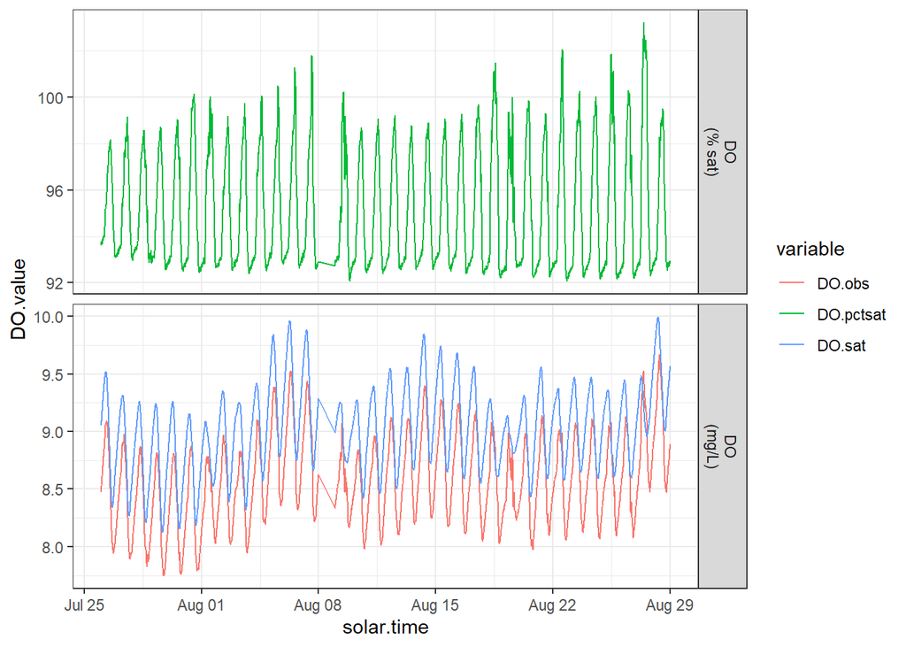

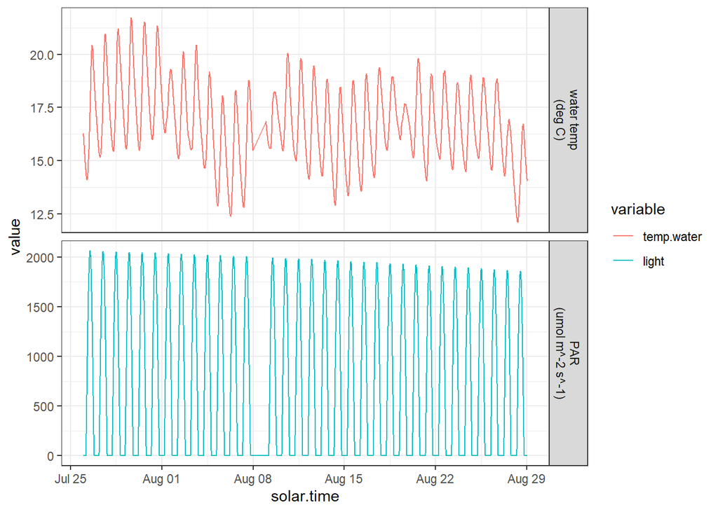

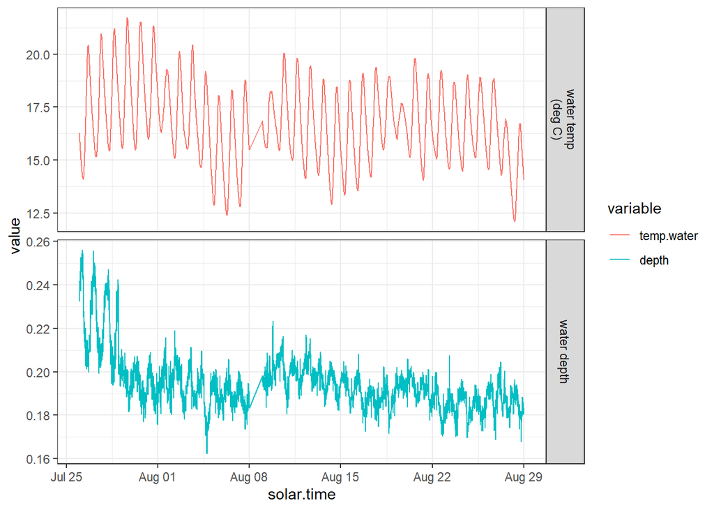

## 4. Configure the model

We will select a Bayesian model. Then we will configure the specs of the model depending on the needs of our run.  
You can play around with the number of iterations (e.g., 100 burnin iterations , also called warm up) and 50 saved steps. You can adjust the number of iterations based on the convergence of the convergence of the model.  
For example, you may start with 1000 and 500 and then up the numbers to 2000 and 1000 if the model results don’t seem to converge.

If you have already adjusted the number of steps multiple times and your model fits are still not good (e.g., negative GPP values) you might have to consider changing other specs in the model. Some examples of variables that you may change are: GPP_daily_lower = 0.01,ER_daily_upper = -0.01. However, you should consult the Help for more information.

Use the command plot_distribs if you want to observe the distribution of the specs if they were changed.

```r
# Set the model

bayes_name = mm_name(type='bayes',
                     pool_K600='normal',
                     err_obs_iid=TRUE,
                     err_proc_iid=TRUE)
bayes_name
```

```
## [1] "b_Kn_oipi_tr_plrckm.stan"
```

```r
 # Options for pool K600 are binned, linear, none and normal. If normal is specified, discharge doesn't need to be provided

# Changing the specs
bayes_specs = specs(bayes_name, K600_daily_meanlog_meanlog=log(K600estimate), K600_daily_meanlog_sdlog=0.7, K600_daily_sdlog_sigma=0.02, burnin_steps=1000,
                  saved_steps=1000,
                  n_cores=10)
```

## 5. Fit the model and save the results

Some key parameters to look at in the mm output are:  
- $daily (includes metabolism estimates) - $overall (includes error information) - $KQ_overall (included the relationship between K600-Q)

```r
mm = metab(bayes_specs, data=dat)#
#load("~/GitHub/gitlab/SSS_metabolism/initial_SM_testing/test_15min.RData")

#Extracting the data from the model output the outputs are in a S4
#class of data and you'll need to operators to extract the daily
#time series of estimates
#get_fit(mm) %>%
  #lapply(names)

# Saving key data
#output.path = paste0(data.output.path,"/Output/")
preds = mm@fit$daily
#str(preds)
write.csv(preds,paste0(output.path,"Results_",file.name,Sys.Date(),".csv"))

instant = mm@fit$inst
#str(instant)
write.csv(instant,paste0(output.path,"Instant_",file.name,Sys.Date(),".csv"))

Overall = mm@fit$overall
#str(Overall)
write.csv(Overall,paste0(output.path,"Overall_",file.name,Sys.Date(),".csv"))

KQ = mm@fit$KQ_overall
#str(KQ)
write.csv(KQ,paste0(output.path,"KQ_ovearll",file.name,Sys.Date(),".csv"))


#get_data(mm)# Shows a table with all the data + DO modeled
#get_data_daily(mm) #daily fitting data. It shows values for Q for now
#get_params(mm)
```

## 6. Inspect GPP, ER and K600

### Daily predictions of modeled GPP and ER

The goal is for the predictions (lines) and observations (points) to be very similar.

```
## # A tibble: 35 x 10
##    date          GPP GPP.lower GPP.upper    ER ER.lower ER.upper msgs.~1 warni~2
##    <date>      <dbl>     <dbl>     <dbl> <dbl>    <dbl>    <dbl> <chr>   <chr>
##  1 2022-07-25 NA        NA        NA     NA       NA       NA    "w    ~ ""
##  2 2022-07-26  0.953     0.612     1.33  -4.73    -6.07    -3.56 "w    ~ ""
##  3 2022-07-27  1.08      0.747     1.49  -4.57    -5.90    -3.52 "w    ~ ""
##  4 2022-07-28  0.789     0.537     1.11  -3.61    -4.64    -2.81 "w    ~ ""
##  5 2022-07-29  0.972     0.639     1.44  -4.44    -6.05    -3.31 "w    ~ ""
##  6 2022-07-30  0.726     0.463     1.01  -3.38    -4.33    -2.53 "w    ~ ""
##  7 2022-07-31  1.36      0.978     1.80  -4.30    -5.47    -3.29 "w    ~ ""
##  8 2022-08-01  0.938     0.712     1.23  -3.12    -3.92    -2.53 "w    ~ ""
##  9 2022-08-02  0.672     0.467     0.964 -3.30    -4.30    -2.63 "w    ~ ""
## 10 2022-08-03  0.658     0.458     0.906 -2.95    -3.72    -2.32 "w    ~ ""
## # ... with 25 more rows, 1 more variable: errors <chr>, and abbreviated
## #   variable names 1: msgs.fit, 2: warnings
```

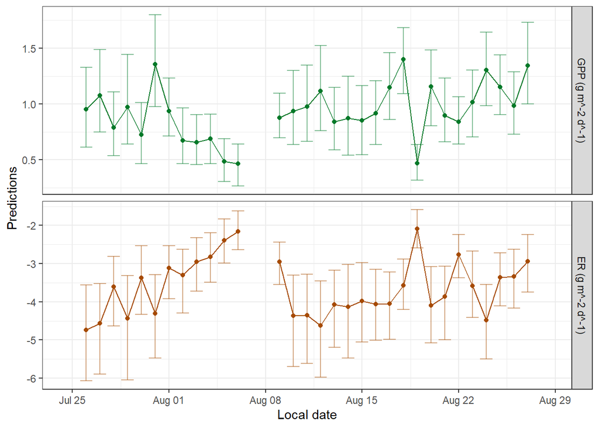

```
## # A tibble: 35 x 9
##    date       GPP.daily GPP.dai~1 ER.da~2 ER.da~3 K600.~4 K600.~5 warni~6 errors
##    <date>         <dbl>     <dbl>   <dbl>   <dbl>   <dbl>   <dbl> <chr>   <chr>
##  1 2022-07-25    NA        NA       NA     NA        NA     NA    overal~ "data~
##  2 2022-07-26     0.956     0.172   -4.74   0.608    37.8    4.39 overal~ ""
##  3 2022-07-27     1.09      0.187   -4.61   0.604    37.1    4.39 overal~ ""
##  4 2022-07-28     0.796     0.142   -3.64   0.461    30.9    3.48 overal~ ""
##  5 2022-07-29     0.989     0.205   -4.50   0.700    39.8    5.63 overal~ ""
##  6 2022-07-30     0.727     0.143   -3.39   0.463    31.2    3.80 overal~ ""
##  7 2022-07-31     1.36      0.208   -4.31   0.553    38.0    4.48 overal~ ""
##  8 2022-08-01     0.947     0.135   -3.15   0.370    29.0    3.07 overal~ ""
##  9 2022-08-02     0.682     0.124   -3.35   0.415    31.0    3.44 overal~ ""
## 10 2022-08-03     0.664     0.113   -2.96   0.351    27.3    2.86 overal~ ""
## # ... with 25 more rows, and abbreviated variable names 1: GPP.daily.sd,
## #   2: ER.daily, 3: ER.daily.sd, 4: K600.daily, 5: K600.daily.sd, 6: warnings
```

```
##         date          solar.time   DO.obs   DO.sat     depth temp.water light
## 1 2022-07-25 2022-07-25 23:58:52 8.475944 9.054822 0.2415507     16.283     0
## 2 2022-07-25 2022-07-26 00:13:52 8.502938 9.078148 0.2355667     16.156     0
## 3 2022-07-25 2022-07-26 00:28:52 8.528893 9.096080 0.2324216     16.079     0
## 4 2022-07-25 2022-07-26 00:43:52 8.538237 9.116056 0.2370932     15.968     0
## 5 2022-07-25 2022-07-26 00:58:52 8.566269 9.141867 0.2417523     15.848     0
## 6 2022-07-25 2022-07-26 01:13:52 8.583918 9.158452 0.2405423     15.754     0
##   DO.mod
## 1     NA
## 2     NA
## 3     NA
## 4     NA
## 5     NA
## 6     NA
```

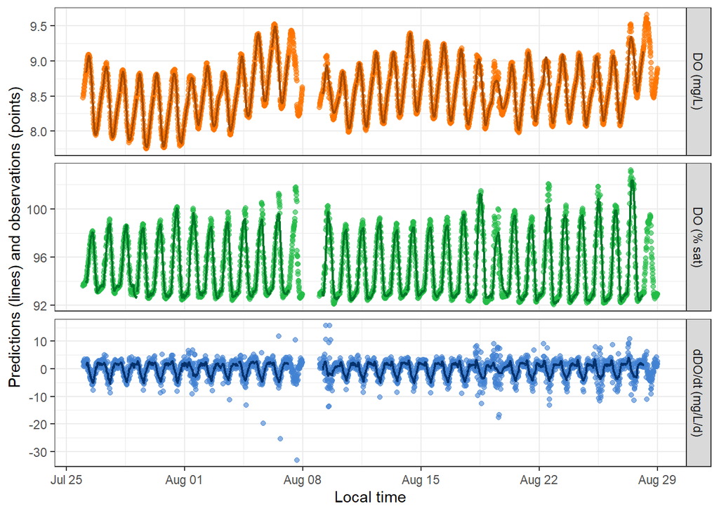

Ideally, good model results should have n_eff > 100 and Rhat < = 1.1. Below is a summary of these metrics for daily GPP, ER and K600.

```
## # A tibble: 35 x 6
##    GPP_Rhat ER_Rhat DO_R2_Rhat GPP_daily_Rhat ER_daily_Rhat K600_daily_Rhat
##       <dbl>   <dbl>      <dbl>          <dbl>         <dbl>           <dbl>
##  1    NA      NA         NA             NA            NA              NA
##  2     1.02    1.03       1.58           1.02          1.03            1.03
##  3     1.02    1.03       1.58           1.02          1.03            1.02
##  4     1.11    1.11       1.60           1.11          1.11            1.11
##  5     1.07    1.07       1.58           1.07          1.07            1.07
##  6     1.12    1.13       1.60           1.12          1.13            1.13
##  7     1.05    1.05       1.57           1.05          1.05            1.05
##  8     1.17    1.17       1.58           1.17          1.17            1.17
##  9     1.05    1.05       1.61           1.05          1.05            1.05
## 10     1.08    1.08       1.60           1.08          1.08            1.08
## # ... with 25 more rows
```

```
##    Min. 1st Qu.  Median    Mean 3rd Qu.    Max.    NA's
##   1.014   1.053   1.084   1.084   1.114   1.171       4
```

```
##    Min. 1st Qu.  Median    Mean 3rd Qu.    Max.    NA's
##   1.013   1.049   1.077   1.079   1.107   1.167       4
```

```
##    Min. 1st Qu.  Median    Mean 3rd Qu.    Max.    NA's
##   1.014   1.054   1.084   1.083   1.114   1.170       4
```

```
## # A tibble: 35 x 6
##    GPP_n_eff ER_n_eff DO_R2_n_eff GPP_daily_n_eff ER_daily_n_eff K600_daily_n_~1
##        <dbl>    <dbl>       <dbl>           <dbl>          <dbl>           <dbl>
##  1      NA       NA         NA               NA             NA              NA
##  2     238.     229.         5.59           238.           229.            232.
##  3     101.      96.8        5.50           101.            96.8            97.1
##  4      45.6     43.9        5.36            45.6           43.9            43.6
##  5      70.4     69.7        5.49            70.4           69.7            70.1
##  6      45.3     42.1        5.30            45.3           42.1            42.4
##  7     105.     108.         5.56           105.           108.            106.
##  8      35.2     35.2        5.47            35.2           35.2            36.0
##  9      71.5     68.5        5.27            71.5           68.5            70.6
## 10      63.8     59.7        5.39            63.8           59.7            59.9
## # ... with 25 more rows, and abbreviated variable name 1: K600_daily_n_eff
```

```
##    Min. 1st Qu.  Median    Mean 3rd Qu.    Max.    NA's
##   21.58   42.25   59.69   64.83   69.10  228.59       4
```

```
##    Min. 1st Qu.  Median    Mean 3rd Qu.    Max.    NA's
##   20.61   42.92   63.18   67.52   77.69  237.71       4
```

```
##    Min. 1st Qu.  Median    Mean 3rd Qu.    Max.    NA's
##   21.20   42.34   55.36   65.21   70.34  231.98       4
```

## 7. Inspect errors and their standard deviations

err_obs_iid_Rhat should have a value < 1.1. Additionally, in a conversation with Allison Appling she mentioned that they have seen pretty frequently err_obs_iid_sigma_Rhats much greater than 1.05, and mentioned it on the [JGR 2018 paper](https://doi.org/10.1002/2017JG004140). This is OK for that particular parameter because the values that the model continues to consider are usually quite similar in absolute magnitudes.

### Inspect err_obs_iid_Rhat and err_obs_iid_sigma_Rhat

```r
#err_obs_iid_Rhat
get_fit(mm)$inst %>%
  select(ends_with('Rhat'))
```

```
## # A tibble: 2,976 x 2
##    err_obs_iid_Rhat err_proc_iid_Rhat
##               <dbl>             <dbl>
##  1            0.999              1.01
##  2            1.00               1.01
##  3            0.999              1.01
##  4            1.00               1.01
##  5            1.00               1.00
##  6            1.00               1.00
##  7            1.00               1.00
##  8            1.00               1.00
##  9            1.00               1.00
## 10            1.00               1.00
## # ... with 2,966 more rows
```

```r
# err_obs_iid_sigma_Rhat. See comment from Appling
get_fit(mm)$overall %>%
  select(ends_with('Rhat'))
```

```
## # A tibble: 1 x 3
##   err_obs_iid_sigma_Rhat err_proc_iid_sigma_Rhat lp___Rhat
##                    <dbl>                   <dbl>     <dbl>
## 1                   1.87                    1.01      2.15
```

```r
get_fit(mm)$inst %>%
  select(ends_with('n_eff'))
```

```
## # A tibble: 2,976 x 2
##    err_obs_iid_n_eff err_proc_iid_n_eff
##                <dbl>              <dbl>
##  1             8006.              1375.
##  2             7402.               822.
##  3             6403.               838.
##  4             5369.               914.
##  5             7158.              2856.
##  6             7999.              3803.
##  7             7864.              3517.
##  8             6830.              3727.
##  9             6339.              3821.
## 10             6629.              3710.
## # ... with 2,966 more rows
```

```r
get_fit(mm)$overall %>%
  select(ends_with('n_eff'))
```

```
## # A tibble: 1 x 3
##   err_obs_iid_sigma_n_eff err_proc_iid_sigma_n_eff lp___n_eff
##                     <dbl>                    <dbl>      <dbl>
## 1                    4.73                     220.       5.22
```

```r
summary(instant$err_obs_iid_n_eff)
```

```
##    Min. 1st Qu.  Median    Mean 3rd Qu.    Max.
##   175.8  6448.5  6932.0  6925.6  7423.3 12084.7
```

```r
summary(instant$err_obs_iid_Rhat)
```

```
##    Min. 1st Qu.  Median    Mean 3rd Qu.    Max.
##  0.9990  0.9994  0.9996  0.9998  0.9999  1.0255
```

```r
summary(instant$err_proc_iid_n_eff)
```

```
##    Min. 1st Qu.  Median    Mean 3rd Qu.    Max.    NA's
##   32.66  379.94 1344.49 1755.56 3054.49 5092.43      31
```

```r
summary(instant$err_proc_iid_Rhat)
```

```
##    Min. 1st Qu.  Median    Mean 3rd Qu.    Max.    NA's
##  0.9991  1.0009  1.0040  1.0103  1.0131  1.1133      31
```

```r
summary(Overall$err_obs_iid_sigma_Rhat)# There is only one err_obs_iid_sigma_Rhat per run
```

```
##    Min. 1st Qu.  Median    Mean 3rd Qu.    Max.
##   1.869   1.869   1.869   1.869   1.869   1.869
```

```r
summary(Overall$err_proc_iid_sigma_Rhat)
```

```
##    Min. 1st Qu.  Median    Mean 3rd Qu.    Max.
##   1.009   1.009   1.009   1.009   1.009   1.009
```

```r
summary(Overall$err_obs_iid_sigma_n_eff)
```

```
##    Min. 1st Qu.  Median    Mean 3rd Qu.    Max.
##    4.73    4.73    4.73    4.73    4.73    4.73
```

```r
summary(Overall$err_proc_iid_sigma_n_eff)
```

```
##    Min. 1st Qu.  Median    Mean 3rd Qu.    Max.
##   220.1   220.1   220.1   220.1   220.1   220.1
```

## 8. Inspect the relationships between variables

### Relationship between K600 and Q: we do not have Q in this experiment, so use depth as a proxy

The first step is to plot K600 and depth, this relationship should be linear??. To find this relationship we have to calculate the mean depth per day and then plot against K600.

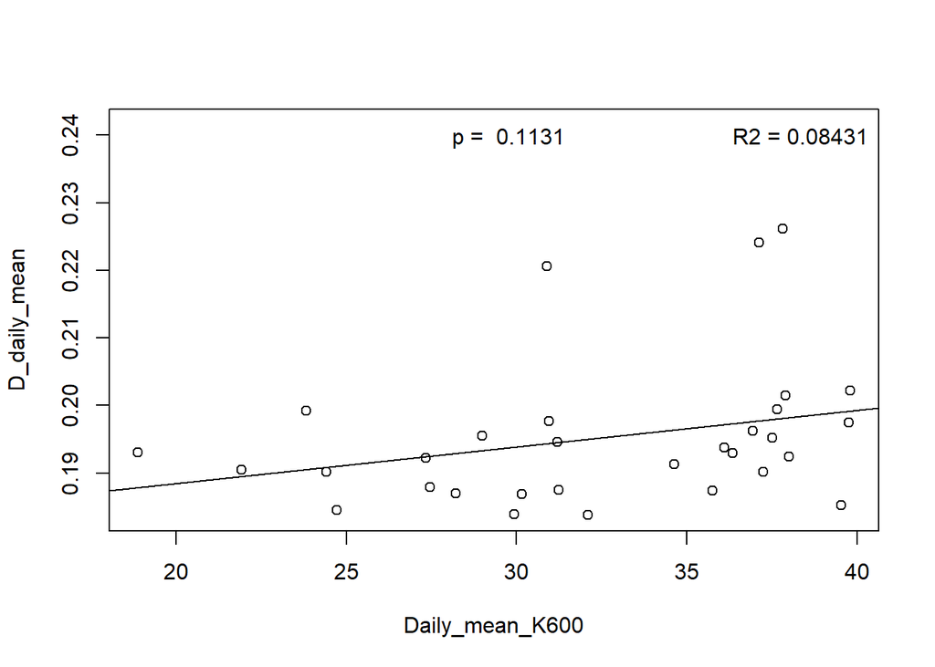

```r
    dat$solar.time = as.Date(dat$solar.time)
    meanDday = aggregate(dat["depth"],by = dat["solar.time"],mean)
    meanDday=meanDday[meanDday$solar.time %in% preds$date,]
    K600D = lm(preds$K600_daily_mean~meanDday$depth)

    plot(preds$K600_daily_mean,meanDday$depth,
         ylab="D_daily_mean",xlab="Daily_mean_K600")
    abline(lm(meanDday$depth~preds$K600_daily_mean))
      legend("topright", bty="n", legend=paste("R2 =", format(summary(K600D)$r.squared, digits=4)))
legend("top", bty="n", legend=paste("p = ", format(summary(K600D)$coefficients[8], digits=4)))
```

```r
    summary(K600D)
```

```
##
## Call:
## lm(formula = preds$K600_daily_mean ~ meanDday$depth)
##
## Residuals:
##      Min       1Q   Median       3Q      Max
## -13.1946  -3.6256   0.2159   4.5526   8.6913
##
## Coefficients:
##                Estimate Std. Error t value Pr(>|t|)
## (Intercept)       1.945     18.664   0.104    0.918
## meanDday$depth  156.032     95.491   1.634    0.113
##
## Residual standard error: 5.628 on 29 degrees of freedom
##   (4 observations deleted due to missingness)
## Multiple R-squared:  0.08431,    Adjusted R-squared:  0.05273
## F-statistic:  2.67 on 1 and 29 DF,  p-value: 0.1131
```

### Relationship between K600 and ER

This relationship is key. Bob Hall says: My primary metric is to look for covariance between ER and K. These have high equifinality which means that any combination of ER or K can provide an equally good fit to the model. If these covary strongly (r=0.6 or higher) then that may not be good for examining controls on variation in ER. If you find **no relationship**, that is a **very good** thing. If there is a relationship, that is if R2 is high, it means that the model can’t parse reaeration from respiration. In this case, ER and K600 are working in opposite for O2, so ideally there is no relationship in the model outputs.

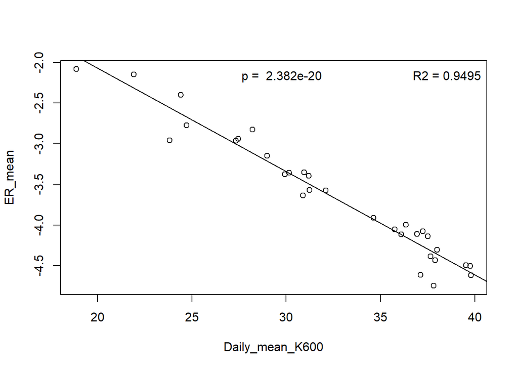

```r
K600ER = lm(K600_daily_mean~ER_mean, data=preds)

    plot(preds$K600_daily_mean,preds$ER_mean,ylab="ER_mean",xlab="Daily_mean_K600")
    abline(lm(ER_mean~K600_daily_mean, data=preds))
    legend("topright", bty="n", legend=paste("R2 =", format(summary(K600ER)$r.squared, digits=4)))
legend("top", bty="n", legend=paste("p = ", format(summary(K600ER)$coefficients[8], digits=4)))
```

```r
 summary(K600ER)
```

```
##
## Call:
## lm(formula = K600_daily_mean ~ ER_mean, data = preds)
##
## Residuals:
##     Min      1Q  Median      3Q     Max
## -3.4413 -0.4150  0.2329  0.7691  1.9326
##
## Coefficients:
##             Estimate Std. Error t value Pr(>|t|)
## (Intercept)   5.1325     1.1916   4.307 0.000173 ***
## ER_mean      -7.4806     0.3204 -23.348  < 2e-16 ***
## ---
## Signif. codes:  0 '***' 0.001 '**' 0.01 '*' 0.05 '.' 0.1 ' ' 1
##
## Residual standard error: 1.322 on 29 degrees of freedom
##   (4 observations deleted due to missingness)
## Multiple R-squared:  0.9495, Adjusted R-squared:  0.9477
## F-statistic: 545.1 on 1 and 29 DF,  p-value: < 2.2e-16
```

### Relationship between K600 and GPP

High GPP is needed to estimate K well, so K should get more variable as GPP decreases.

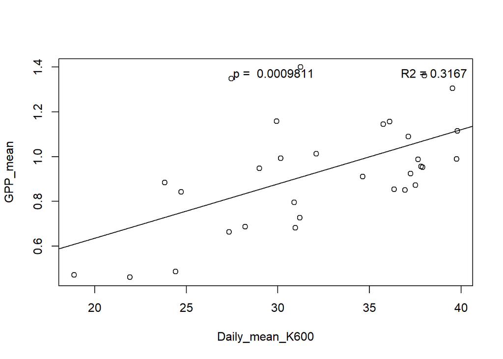

```r
K600GPP = lm(GPP_mean~K600_daily_mean, data=preds)


    plot(preds$K600_daily_mean,preds$GPP_mean,ylab="GPP_mean",xlab="Daily_mean_K600")
    abline(lm(GPP_mean~K600_daily_mean, data=preds))
    legend("topright", bty="n", legend=paste("R2 =", format(summary(K600GPP)$r.squared, digits=4)))
legend("top", bty="n", legend=paste("p = ", format(summary(K600GPP)$coefficients[8], digits=4)))
```

```r
    summary(K600GPP)
```

```
##
## Call:
## lm(formula = GPP_mean ~ K600_daily_mean, data = preds)
##
## Residuals:
##     Min      1Q  Median      3Q     Max
## -0.2560 -0.1495 -0.0798  0.1183  0.5307
##
## Coefficients:
##                 Estimate Std. Error t value Pr(>|t|)
## (Intercept)     0.153790   0.216682   0.710 0.483528
## K600_daily_mean 0.024154   0.006588   3.667 0.000981 ***
## ---
## Signif. codes:  0 '***' 0.001 '**' 0.01 '*' 0.05 '.' 0.1 ' ' 1
##
## Residual standard error: 0.2086 on 29 degrees of freedom
##   (4 observations deleted due to missingness)
## Multiple R-squared:  0.3167, Adjusted R-squared:  0.2932
## F-statistic: 13.44 on 1 and 29 DF,  p-value: 0.0009811
```

### Time series daily mean K600

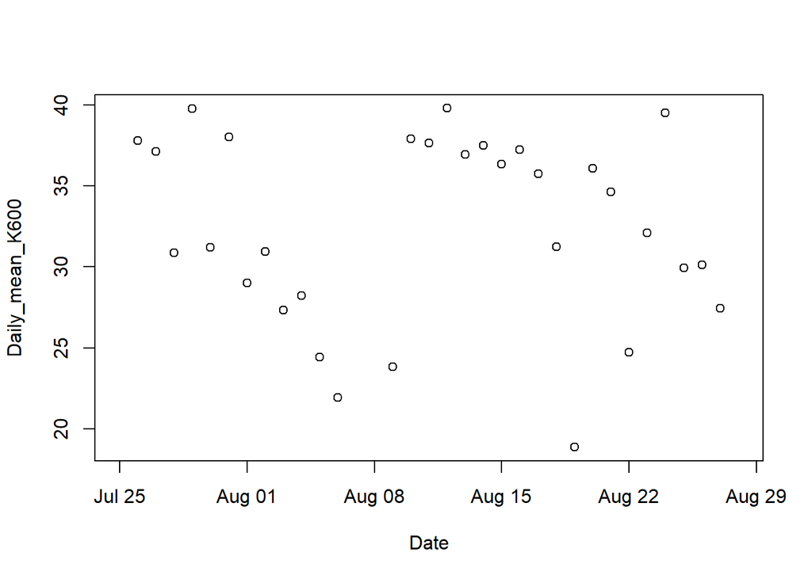

```r
    preds$date = as.Date(preds$date)

    plot(preds$date,preds$K600_daily_mean,
         xlab="Date",ylab="Daily_mean_K600")
```